# Risk Factor Analysis

## Outcome Variable

**Outcome Variable:** wast_rec90d

## Predictor Variables

**Intervention Variable:** enstunt

**Adjustment Set:**

unadjusted

## Stratifying Variables

The analysis was stratified on these variable(s):

- agecat
- studyid
- country

## Data Summary

| agecat | studyid | country | enstunt | wast_rec90d | n_cell | n |
| --- | --- | --- | --- | --- | --- | --- |
| 0-24 months | CMC-V-BCS-2002 | INDIA | 0 | 0 | 88 | 324 |
| 0-24 months | CMC-V-BCS-2002 | INDIA | 0 | 1 | 159 | 324 |
| 0-24 months | CMC-V-BCS-2002 | INDIA | 1 | 0 | 32 | 324 |
| 0-24 months | CMC-V-BCS-2002 | INDIA | 1 | 1 | 45 | 324 |
| 0-24 months | CMIN | BANGLADESH | 0 | 0 | 40 | 190 |
| 0-24 months | CMIN | BANGLADESH | 0 | 1 | 68 | 190 |
| 0-24 months | CMIN | BANGLADESH | 1 | 0 | 40 | 190 |
| 0-24 months | CMIN | BANGLADESH | 1 | 1 | 42 | 190 |
| 0-24 months | COHORTS | GUATEMALA | 0 | 0 | 141 | 381 |
| 0-24 months | COHORTS | GUATEMALA | 0 | 1 | 167 | 381 |
| 0-24 months | COHORTS | GUATEMALA | 1 | 0 | 72 | 381 |
| 0-24 months | COHORTS | GUATEMALA | 1 | 1 | 1 | 381 |
| 0-24 months | COHORTS | INDIA | 0 | 0 | 1674 | 2663 |
| 0-24 months | COHORTS | INDIA | 0 | 1 | 622 | 2663 |
| 0-24 months | COHORTS | INDIA | 1 | 0 | 345 | 2663 |
| 0-24 months | COHORTS | INDIA | 1 | 1 | 22 | 2663 |
| 0-24 months | COHORTS | PHILIPPINES | 0 | 0 | 604 | 1689 |
| 0-24 months | COHORTS | PHILIPPINES | 0 | 1 | 964 | 1689 |
| 0-24 months | COHORTS | PHILIPPINES | 1 | 0 | 60 | 1689 |
| 0-24 months | COHORTS | PHILIPPINES | 1 | 1 | 61 | 1689 |
| 0-24 months | CONTENT | PERU | 0 | 0 | 1 | 7 |
| 0-24 months | CONTENT | PERU | 0 | 1 | 5 | 7 |
| 0-24 months | CONTENT | PERU | 1 | 0 | 0 | 7 |
| 0-24 months | CONTENT | PERU | 1 | 1 | 1 | 7 |
| 0-24 months | EE | PAKISTAN | 0 | 0 | 77 | 323 |
| 0-24 months | EE | PAKISTAN | 0 | 1 | 95 | 323 |
| 0-24 months | EE | PAKISTAN | 1 | 0 | 83 | 323 |
| 0-24 months | EE | PAKISTAN | 1 | 1 | 68 | 323 |
| 0-24 months | GMS-Nepal | NEPAL | 0 | 0 | 249 | 643 |
| 0-24 months | GMS-Nepal | NEPAL | 0 | 1 | 300 | 643 |

[output cut: 314 more lines]

The following strata were considered:

- agecat: 0-24 months, studyid: CMC-V-BCS-2002, country: INDIA
- agecat: 0-24 months, studyid: CMIN, country: BANGLADESH
- agecat: 0-24 months, studyid: COHORTS, country: GUATEMALA
- agecat: 0-24 months, studyid: COHORTS, country: INDIA
- agecat: 0-24 months, studyid: COHORTS, country: PHILIPPINES
- agecat: 0-24 months, studyid: CONTENT, country: PERU
- agecat: 0-24 months, studyid: EE, country: PAKISTAN
- agecat: 0-24 months, studyid: GMS-Nepal, country: NEPAL
- agecat: 0-24 months, studyid: Guatemala BSC, country: GUATEMALA
- agecat: 0-24 months, studyid: iLiNS-Zinc, country: BURKINA FASO
- agecat: 0-24 months, studyid: IRC, country: INDIA
- agecat: 0-24 months, studyid: Keneba, country: GAMBIA
- agecat: 0-24 months, studyid: LCNI-5, country: MALAWI
- agecat: 0-24 months, studyid: MAL-ED, country: BANGLADESH
- agecat: 0-24 months, studyid: MAL-ED, country: BRAZIL
- agecat: 0-24 months, studyid: MAL-ED, country: INDIA
- agecat: 0-24 months, studyid: MAL-ED, country: NEPAL
- agecat: 0-24 months, studyid: MAL-ED, country: PERU
- agecat: 0-24 months, studyid: MAL-ED, country: SOUTH AFRICA
- agecat: 0-24 months, studyid: MAL-ED, country: TANZANIA, UNITED REPUBLIC OF
- agecat: 0-24 months, studyid: NIH-Birth, country: BANGLADESH
- agecat: 0-24 months, studyid: NIH-Crypto, country: BANGLADESH
- agecat: 0-24 months, studyid: PROBIT, country: BELARUS
- agecat: 0-24 months, studyid: PROVIDE, country: BANGLADESH
- agecat: 0-24 months, studyid: ResPak, country: PAKISTAN
- agecat: 0-24 months, studyid: SAS-CompFeed, country: INDIA
- agecat: 0-24 months, studyid: SAS-FoodSuppl, country: INDIA
- agecat: 0-24 months, studyid: TanzaniaChild2, country: TANZANIA, UNITED REPUBLIC OF
- agecat: 0-24 months, studyid: ZVITAMBO, country: ZIMBABWE
- agecat: 0-6 months, studyid: CMC-V-BCS-2002, country: INDIA
- agecat: 0-6 months, studyid: CMIN, country: BANGLADESH
- agecat: 0-6 months, studyid: COHORTS, country: GUATEMALA
- agecat: 0-6 months, studyid: COHORTS, country: INDIA
- agecat: 0-6 months, studyid: COHORTS, country: PHILIPPINES
- agecat: 0-6 months, studyid: CONTENT, country: PERU
- agecat: 0-6 months, studyid: EE, country: PAKISTAN
- agecat: 0-6 months, studyid: GMS-Nepal, country: NEPAL
- agecat: 0-6 months, studyid: Guatemala BSC, country: GUATEMALA
- agecat: 0-6 months, studyid: IRC, country: INDIA
- agecat: 0-6 months, studyid: Keneba, country: GAMBIA
- agecat: 0-6 months, studyid: LCNI-5, country: MALAWI
- agecat: 0-6 months, studyid: MAL-ED, country: BANGLADESH
- agecat: 0-6 months, studyid: MAL-ED, country: BRAZIL
- agecat: 0-6 months, studyid: MAL-ED, country: INDIA
- agecat: 0-6 months, studyid: MAL-ED, country: NEPAL
- agecat: 0-6 months, studyid: MAL-ED, country: PERU
- agecat: 0-6 months, studyid: MAL-ED, country: SOUTH AFRICA
- agecat: 0-6 months, studyid: MAL-ED, country: TANZANIA, UNITED REPUBLIC OF
- agecat: 0-6 months, studyid: NIH-Birth, country: BANGLADESH
- agecat: 0-6 months, studyid: NIH-Crypto, country: BANGLADESH
- agecat: 0-6 months, studyid: PROBIT, country: BELARUS
- agecat: 0-6 months, studyid: PROVIDE, country: BANGLADESH
- agecat: 0-6 months, studyid: ResPak, country: PAKISTAN
- agecat: 0-6 months, studyid: SAS-CompFeed, country: INDIA
- agecat: 0-6 months, studyid: SAS-FoodSuppl, country: INDIA
- agecat: 0-6 months, studyid: TanzaniaChild2, country: TANZANIA, UNITED REPUBLIC OF
- agecat: 0-6 months, studyid: ZVITAMBO, country: ZIMBABWE
- agecat: 6-24 months, studyid: CMC-V-BCS-2002, country: INDIA
- agecat: 6-24 months, studyid: CMIN, country: BANGLADESH
- agecat: 6-24 months, studyid: COHORTS, country: GUATEMALA
- agecat: 6-24 months, studyid: COHORTS, country: INDIA
- agecat: 6-24 months, studyid: COHORTS, country: PHILIPPINES
- agecat: 6-24 months, studyid: CONTENT, country: PERU
- agecat: 6-24 months, studyid: EE, country: PAKISTAN
- agecat: 6-24 months, studyid: GMS-Nepal, country: NEPAL
- agecat: 6-24 months, studyid: Guatemala BSC, country: GUATEMALA
- agecat: 6-24 months, studyid: iLiNS-Zinc, country: BURKINA FASO
- agecat: 6-24 months, studyid: IRC, country: INDIA
- agecat: 6-24 months, studyid: Keneba, country: GAMBIA
- agecat: 6-24 months, studyid: LCNI-5, country: MALAWI
- agecat: 6-24 months, studyid: MAL-ED, country: BANGLADESH
- agecat: 6-24 months, studyid: MAL-ED, country: BRAZIL
- agecat: 6-24 months, studyid: MAL-ED, country: INDIA
- agecat: 6-24 months, studyid: MAL-ED, country: NEPAL
- agecat: 6-24 months, studyid: MAL-ED, country: PERU
- agecat: 6-24 months, studyid: MAL-ED, country: SOUTH AFRICA
- agecat: 6-24 months, studyid: MAL-ED, country: TANZANIA, UNITED REPUBLIC OF
- agecat: 6-24 months, studyid: NIH-Birth, country: BANGLADESH
- agecat: 6-24 months, studyid: NIH-Crypto, country: BANGLADESH
- agecat: 6-24 months, studyid: PROBIT, country: BELARUS
- agecat: 6-24 months, studyid: PROVIDE, country: BANGLADESH
- agecat: 6-24 months, studyid: ResPak, country: PAKISTAN
- agecat: 6-24 months, studyid: SAS-CompFeed, country: INDIA
- agecat: 6-24 months, studyid: SAS-FoodSuppl, country: INDIA
- agecat: 6-24 months, studyid: TanzaniaChild2, country: TANZANIA, UNITED REPUBLIC OF
- agecat: 6-24 months, studyid: ZVITAMBO, country: ZIMBABWE

### Dropped Strata

Some strata were dropped due to rare outcomes:

- agecat: 0-24 months, studyid: COHORTS, country: GUATEMALA
- agecat: 0-24 months, studyid: CONTENT, country: PERU
- agecat: 0-24 months, studyid: MAL-ED, country: BRAZIL
- agecat: 0-24 months, studyid: MAL-ED, country: NEPAL
- agecat: 0-24 months, studyid: MAL-ED, country: PERU
- agecat: 0-24 months, studyid: MAL-ED, country: SOUTH AFRICA
- agecat: 0-24 months, studyid: MAL-ED, country: TANZANIA, UNITED REPUBLIC OF
- agecat: 0-24 months, studyid: PROBIT, country: BELARUS
- agecat: 0-24 months, studyid: SAS-FoodSuppl, country: INDIA
- agecat: 0-6 months, studyid: COHORTS, country: GUATEMALA
- agecat: 0-6 months, studyid: CONTENT, country: PERU
- agecat: 0-6 months, studyid: Guatemala BSC, country: GUATEMALA
- agecat: 0-6 months, studyid: LCNI-5, country: MALAWI
- agecat: 0-6 months, studyid: MAL-ED, country: BANGLADESH
- agecat: 0-6 months, studyid: MAL-ED, country: BRAZIL
- agecat: 0-6 months, studyid: MAL-ED, country: INDIA
- agecat: 0-6 months, studyid: MAL-ED, country: NEPAL
- agecat: 0-6 months, studyid: MAL-ED, country: PERU
- agecat: 0-6 months, studyid: MAL-ED, country: SOUTH AFRICA
- agecat: 0-6 months, studyid: MAL-ED, country: TANZANIA, UNITED REPUBLIC OF
- agecat: 0-6 months, studyid: NIH-Crypto, country: BANGLADESH
- agecat: 0-6 months, studyid: PROBIT, country: BELARUS
- agecat: 0-6 months, studyid: SAS-FoodSuppl, country: INDIA
- agecat: 0-6 months, studyid: TanzaniaChild2, country: TANZANIA, UNITED REPUBLIC OF
- agecat: 6-24 months, studyid: COHORTS, country: GUATEMALA
- agecat: 6-24 months, studyid: COHORTS, country: INDIA
- agecat: 6-24 months, studyid: CONTENT, country: PERU
- agecat: 6-24 months, studyid: MAL-ED, country: BRAZIL
- agecat: 6-24 months, studyid: MAL-ED, country: NEPAL
- agecat: 6-24 months, studyid: MAL-ED, country: PERU
- agecat: 6-24 months, studyid: MAL-ED, country: SOUTH AFRICA
- agecat: 6-24 months, studyid: MAL-ED, country: TANZANIA, UNITED REPUBLIC OF
- agecat: 6-24 months, studyid: NIH-Crypto, country: BANGLADESH
- agecat: 6-24 months, studyid: PROBIT, country: BELARUS
- agecat: 6-24 months, studyid: SAS-FoodSuppl, country: INDIA

## Methods Detail

We’re interested in the causal parameters $E[Y_a]$ for all values of $a \in \mathcal{A}$. These parameters represent the mean outcome if, possibly contrary to fact, we intervened to set all units to have $A=a$. Under the randomization and positivity assumptions, these are identified by the statistical parameters $\psi_a=E_W[E_{Y|A,W}(Y|A=a,W)]$. In addition, we’re interested in the mean of $Y$, $E[Y]$ under no intervention (the observed mean). We will estimate these parameters by using SuperLearner to fit the relevant likelihood factors – $E_{Y|A,W}(Y|A=a,W)$ and $p(A=a|W)$, and then updating our likelihood fit using a joint TMLE.

For unadjusted analyses ($W=\{\}$), initial likelihoods were estimated using Lrnr_glm to estimate the simple $E(Y|A)$ and Lrnr_mean to estimate $p(A)$. For adjusted analyses, a small library containing Lrnr_glmnet, Lrnr_xgboost, and Lrnr_mean was used.

Having estimated these parameters, we will then use the delta method to estimate relative risks and attributable risks relative to a prespecified baseline level of $A$.

# Results Detail

## Results Plots

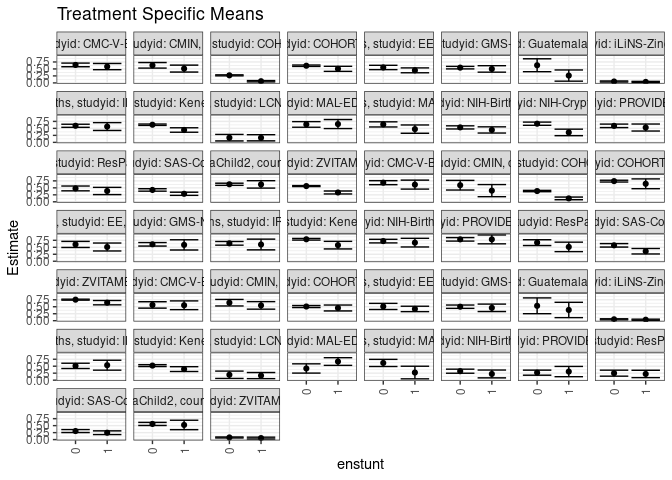

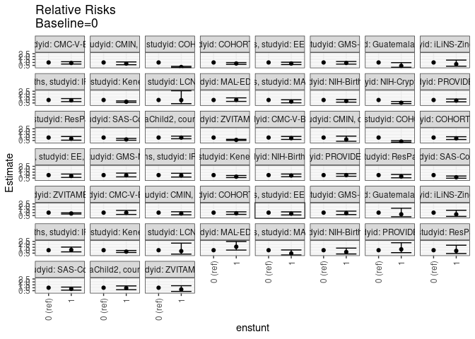

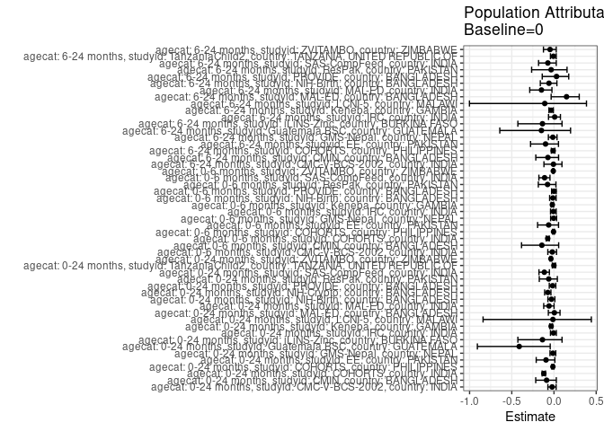

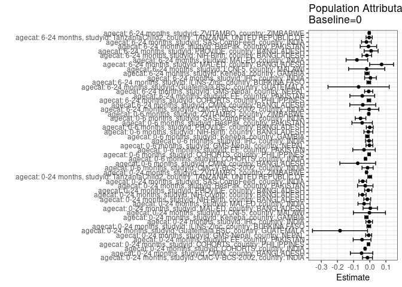

## Results Table

### Parameter: TSM

| agecat | studyid | country | intervention_level | baseline_level | estimate | ci_lower | ci_upper |
| --- | --- | --- | --- | --- | --- | --- | --- |
| 0-24 months | CMC-V-BCS-2002 | INDIA | 0 | NA | 0.6437247 | 0.5788596 | 0.7085898 |
| 0-24 months | CMC-V-BCS-2002 | INDIA | 1 | NA | 0.5844156 | 0.4726395 | 0.6961917 |
| 0-24 months | CMIN | BANGLADESH | 0 | NA | 0.6296296 | 0.5302299 | 0.7290293 |
| 0-24 months | CMIN | BANGLADESH | 1 | NA | 0.5121951 | 0.3881411 | 0.6362492 |
| 0-24 months | COHORTS | INDIA | 0 | NA | 0.2709059 | 0.2526274 | 0.2891844 |
| 0-24 months | COHORTS | INDIA | 1 | NA | 0.0599455 | 0.0368446 | 0.0830464 |
| 0-24 months | COHORTS | PHILIPPINES | 0 | NA | 0.6147959 | 0.5894343 | 0.6401575 |
| 0-24 months | COHORTS | PHILIPPINES | 1 | NA | 0.5041322 | 0.4133509 | 0.5949136 |
| 0-24 months | EE | PAKISTAN | 0 | NA | 0.5523256 | 0.4743712 | 0.6302800 |
| 0-24 months | EE | PAKISTAN | 1 | NA | 0.4503311 | 0.3631570 | 0.5375053 |
| 0-24 months | GMS-Nepal | NEPAL | 0 | NA | 0.5464481 | 0.5010763 | 0.5918199 |
| 0-24 months | GMS-Nepal | NEPAL | 1 | NA | 0.5000000 | 0.3845665 | 0.6154335 |
| 0-24 months | Guatemala BSC | GUATEMALA | 0 | NA | 0.6315789 | 0.4004047 | 0.8627532 |
| 0-24 months | Guatemala BSC | GUATEMALA | 1 | NA | 0.2631579 | 0.0627483 | 0.4635675 |
| 0-24 months | iLiNS-Zinc | BURKINA FASO | 0 | NA | 0.0498960 | 0.0305391 | 0.0692530 |
| 0-24 months | iLiNS-Zinc | BURKINA FASO | 1 | NA | 0.0353982 | 0.0154672 | 0.0553292 |
| 0-24 months | IRC | INDIA | 0 | NA | 0.5935673 | 0.5375254 | 0.6496091 |
| 0-24 months | IRC | INDIA | 1 | NA | 0.5660377 | 0.4252861 | 0.7067894 |
| 0-24 months | Keneba | GAMBIA | 0 | NA | 0.6312231 | 0.6063228 | 0.6561234 |
| 0-24 months | Keneba | GAMBIA | 1 | NA | 0.4427861 | 0.3628149 | 0.5227573 |
| 0-24 months | LCNI-5 | MALAWI | 0 | NA | 0.1666667 | 0.0503410 | 0.2829923 |
| 0-24 months | LCNI-5 | MALAWI | 1 | NA | 0.1632653 | 0.0532454 | 0.2732852 |
| 0-24 months | MAL-ED | BANGLADESH | 0 | NA | 0.6421053 | 0.5415390 | 0.7426715 |
| 0-24 months | MAL-ED | BANGLADESH | 1 | NA | 0.6551724 | 0.4931883 | 0.8171566 |
| 0-24 months | MAL-ED | INDIA | 0 | NA | 0.6433566 | 0.5516582 | 0.7350551 |
| 0-24 months | MAL-ED | INDIA | 1 | NA | 0.4736842 | 0.3251440 | 0.6222245 |
| 0-24 months | NIH-Birth | BANGLADESH | 0 | NA | 0.5358166 | 0.4794069 | 0.5922263 |
| 0-24 months | NIH-Birth | BANGLADESH | 1 | NA | 0.4444444 | 0.3334788 | 0.5554101 |
| 0-24 months | NIH-Crypto | BANGLADESH | 0 | NA | 0.6679245 | 0.6101642 | 0.7256848 |
| 0-24 months | NIH-Crypto | BANGLADESH | 1 | NA | 0.3555556 | 0.2390941 | 0.4720170 |

[output cut: 72 more lines]

### Parameter: E(Y)

| agecat | studyid | country | intervention_level | baseline_level | estimate | ci_lower | ci_upper |
| --- | --- | --- | --- | --- | --- | --- | --- |
| 0-24 months | CMC-V-BCS-2002 | INDIA | NA | NA | 0.6296296 | 0.5734927 | 0.6857666 |
| 0-24 months | CMIN | BANGLADESH | NA | NA | 0.5789474 | 0.5004470 | 0.6574477 |
| 0-24 months | COHORTS | INDIA | NA | NA | 0.2418325 | 0.2254819 | 0.2581831 |
| 0-24 months | COHORTS | PHILIPPINES | NA | NA | 0.6068680 | 0.5823645 | 0.6313715 |
| 0-24 months | EE | PAKISTAN | NA | NA | 0.5046440 | 0.4456009 | 0.5636870 |
| 0-24 months | GMS-Nepal | NEPAL | NA | NA | 0.5396579 | 0.4973524 | 0.5819633 |
| 0-24 months | Guatemala BSC | GUATEMALA | NA | NA | 0.4473684 | 0.2760904 | 0.6186464 |
| 0-24 months | iLiNS-Zinc | BURKINA FASO | NA | NA | 0.0439024 | 0.0298653 | 0.0579396 |
| 0-24 months | IRC | INDIA | NA | NA | 0.5898734 | 0.5376978 | 0.6420491 |
| 0-24 months | Keneba | GAMBIA | NA | NA | 0.6105033 | 0.5863646 | 0.6346419 |
| 0-24 months | LCNI-5 | MALAWI | NA | NA | 0.1645570 | 0.0832789 | 0.2458350 |
| 0-24 months | MAL-ED | BANGLADESH | NA | NA | 0.6451613 | 0.5593015 | 0.7310211 |
| 0-24 months | MAL-ED | INDIA | NA | NA | 0.6077348 | 0.5286689 | 0.6868008 |
| 0-24 months | NIH-Birth | BANGLADESH | NA | NA | 0.5201900 | 0.4695846 | 0.5707955 |
| 0-24 months | NIH-Crypto | BANGLADESH | NA | NA | 0.6225806 | 0.5684562 | 0.6767051 |
| 0-24 months | PROVIDE | BANGLADESH | NA | NA | 0.5811688 | 0.5245443 | 0.6377934 |
| 0-24 months | ResPak | PAKISTAN | NA | NA | 0.4509804 | 0.3794254 | 0.5225353 |
| 0-24 months | SAS-CompFeed | INDIA | NA | NA | 0.3808354 | 0.3457640 | 0.4159068 |
| 0-24 months | TanzaniaChild2 | TANZANIA, UNITED REPUBLIC OF | NA | NA | 0.6269285 | 0.5892870 | 0.6645700 |
| 0-24 months | ZVITAMBO | ZIMBABWE | NA | NA | 0.5432918 | 0.5268968 | 0.5596869 |
| 0-6 months | CMC-V-BCS-2002 | INDIA | NA | NA | 0.6716418 | 0.6057305 | 0.7375531 |
| 0-6 months | CMIN | BANGLADESH | NA | NA | 0.5192308 | 0.3806687 | 0.6577929 |
| 0-6 months | COHORTS | INDIA | NA | NA | 0.3585746 | 0.3363886 | 0.3807606 |
| 0-6 months | COHORTS | PHILIPPINES | NA | NA | 0.7367021 | 0.7051294 | 0.7682749 |
| 0-6 months | EE | PAKISTAN | NA | NA | 0.5669291 | 0.4800274 | 0.6538309 |
| 0-6 months | GMS-Nepal | NEPAL | NA | NA | 0.6045627 | 0.5449300 | 0.6641955 |
| 0-6 months | IRC | INDIA | NA | NA | 0.6375000 | 0.5751450 | 0.6998550 |
| 0-6 months | Keneba | GAMBIA | NA | NA | 0.7720994 | 0.7419223 | 0.8022766 |
| 0-6 months | NIH-Birth | BANGLADESH | NA | NA | 0.7130045 | 0.6535890 | 0.7724200 |
| 0-6 months | PROVIDE | BANGLADESH | NA | NA | 0.7837838 | 0.7252863 | 0.8422812 |
| 0-6 months | ResPak | PAKISTAN | NA | NA | 0.6194690 | 0.5292383 | 0.7096997 |
| 0-6 months | SAS-CompFeed | INDIA | NA | NA | 0.5131965 | 0.4596632 | 0.5667297 |
| 0-6 months | ZVITAMBO | ZIMBABWE | NA | NA | 0.7475189 | 0.7305656 | 0.7644721 |
| 6-24 months | CMC-V-BCS-2002 | INDIA | NA | NA | 0.5609756 | 0.4682842 | 0.6536670 |
| 6-24 months | CMIN | BANGLADESH | NA | NA | 0.6014493 | 0.5131344 | 0.6897641 |
| 6-24 months | COHORTS | PHILIPPINES | NA | NA | 0.5026681 | 0.4688378 | 0.5364984 |
| 6-24 months | EE | PAKISTAN | NA | NA | 0.4642857 | 0.3910729 | 0.5374985 |
| 6-24 months | GMS-Nepal | NEPAL | NA | NA | 0.4947368 | 0.4401559 | 0.5493178 |
| 6-24 months | Guatemala BSC | GUATEMALA | NA | NA | 0.4642857 | 0.2621560 | 0.6664155 |
| 6-24 months | iLiNS-Zinc | BURKINA FASO | NA | NA | 0.0439024 | 0.0298653 | 0.0579396 |
| 6-24 months | IRC | INDIA | NA | NA | 0.5161290 | 0.4322562 | 0.6000019 |
| 6-24 months | Keneba | GAMBIA | NA | NA | 0.5045290 | 0.4730969 | 0.5359611 |
| 6-24 months | LCNI-5 | MALAWI | NA | NA | 0.1733333 | 0.0886479 | 0.2580188 |
| 6-24 months | MAL-ED | BANGLADESH | NA | NA | 0.4918033 | 0.3610932 | 0.6225134 |
| 6-24 months | MAL-ED | INDIA | NA | NA | 0.5368421 | 0.4223932 | 0.6512910 |
| 6-24 months | NIH-Birth | BANGLADESH | NA | NA | 0.3030303 | 0.2377927 | 0.3682679 |
| 6-24 months | PROVIDE | BANGLADESH | NA | NA | 0.2764228 | 0.1950773 | 0.3577682 |
| 6-24 months | ResPak | PAKISTAN | NA | NA | 0.2417582 | 0.1565924 | 0.3269241 |
| 6-24 months | SAS-CompFeed | INDIA | NA | NA | 0.2854123 | 0.2436284 | 0.3271961 |
| 6-24 months | TanzaniaChild2 | TANZANIA, UNITED REPUBLIC OF | NA | NA | 0.5576408 | 0.5054408 | 0.6098407 |
| 6-24 months | ZVITAMBO | ZIMBABWE | NA | NA | 0.0739051 | 0.0584895 | 0.0893208 |

### Parameter: RR

| agecat | studyid | country | intervention_level | baseline_level | estimate | ci_lower | ci_upper |
| --- | --- | --- | --- | --- | --- | --- | --- |
| 0-24 months | CMC-V-BCS-2002 | INDIA | 0 | 0 | 1.0000000 | 1.0000000 | 1.0000000 |
| 0-24 months | CMC-V-BCS-2002 | INDIA | 1 | 0 | 0.9078657 | 0.7313527 | 1.1269804 |
| 0-24 months | CMIN | BANGLADESH | 0 | 0 | 1.0000000 | 1.0000000 | 1.0000000 |
| 0-24 months | CMIN | BANGLADESH | 1 | 0 | 0.8134864 | 0.6092446 | 1.0861977 |
| 0-24 months | COHORTS | INDIA | 0 | 0 | 1.0000000 | 1.0000000 | 1.0000000 |
| 0-24 months | COHORTS | INDIA | 1 | 0 | 0.2212779 | 0.1496338 | 0.3272251 |
| 0-24 months | COHORTS | PHILIPPINES | 0 | 0 | 1.0000000 | 1.0000000 | 1.0000000 |
| 0-24 months | COHORTS | PHILIPPINES | 1 | 0 | 0.8199993 | 0.6816895 | 0.9863712 |
| 0-24 months | EE | PAKISTAN | 0 | 0 | 1.0000000 | 1.0000000 | 1.0000000 |
| 0-24 months | EE | PAKISTAN | 1 | 0 | 0.8153364 | 0.6417975 | 1.0357992 |
| 0-24 months | GMS-Nepal | NEPAL | 0 | 0 | 1.0000000 | 1.0000000 | 1.0000000 |
| 0-24 months | GMS-Nepal | NEPAL | 1 | 0 | 0.9150000 | 0.7158648 | 1.1695296 |
| 0-24 months | Guatemala BSC | GUATEMALA | 0 | 0 | 1.0000000 | 1.0000000 | 1.0000000 |
| 0-24 months | Guatemala BSC | GUATEMALA | 1 | 0 | 0.4166667 | 0.1790304 | 0.9697297 |
| 0-24 months | iLiNS-Zinc | BURKINA FASO | 0 | 0 | 1.0000000 | 1.0000000 | 1.0000000 |
| 0-24 months | iLiNS-Zinc | BURKINA FASO | 1 | 0 | 0.7094395 | 0.3580644 | 1.4056253 |
| 0-24 months | IRC | INDIA | 0 | 0 | 1.0000000 | 1.0000000 | 1.0000000 |
| 0-24 months | IRC | INDIA | 1 | 0 | 0.9536202 | 0.7310186 | 1.2440060 |
| 0-24 months | Keneba | GAMBIA | 0 | 0 | 1.0000000 | 1.0000000 | 1.0000000 |
| 0-24 months | Keneba | GAMBIA | 1 | 0 | 0.7014732 | 0.5830783 | 0.8439082 |
| 0-24 months | LCNI-5 | MALAWI | 0 | 0 | 1.0000000 | 1.0000000 | 1.0000000 |
| 0-24 months | LCNI-5 | MALAWI | 1 | 0 | 0.9795918 | 0.3712732 | 2.5846201 |
| 0-24 months | MAL-ED | BANGLADESH | 0 | 0 | 1.0000000 | 1.0000000 | 1.0000000 |
| 0-24 months | MAL-ED | BANGLADESH | 1 | 0 | 1.0203505 | 0.7616227 | 1.3669696 |
| 0-24 months | MAL-ED | INDIA | 0 | 0 | 1.0000000 | 1.0000000 | 1.0000000 |
| 0-24 months | MAL-ED | INDIA | 1 | 0 | 0.7362700 | 0.5218973 | 1.0386976 |
| 0-24 months | NIH-Birth | BANGLADESH | 0 | 0 | 1.0000000 | 1.0000000 | 1.0000000 |
| 0-24 months | NIH-Birth | BANGLADESH | 1 | 0 | 0.8294712 | 0.6325587 | 1.0876816 |
| 0-24 months | NIH-Crypto | BANGLADESH | 0 | 0 | 1.0000000 | 1.0000000 | 1.0000000 |
| 0-24 months | NIH-Crypto | BANGLADESH | 1 | 0 | 0.5323289 | 0.3793754 | 0.7469490 |

[output cut: 72 more lines]

### Parameter: PAR

| agecat | studyid | country | intervention_level | baseline_level | estimate | ci_lower | ci_upper |
| --- | --- | --- | --- | --- | --- | --- | --- |
| 0-24 months | CMC-V-BCS-2002 | INDIA | 0 | NA | -0.0140951 | -0.0448035 | 0.0166134 |
| 0-24 months | CMIN | BANGLADESH | 0 | NA | -0.0506823 | -0.1200753 | 0.0187108 |
| 0-24 months | COHORTS | INDIA | 0 | NA | -0.0290734 | -0.0341181 | -0.0240287 |
| 0-24 months | COHORTS | PHILIPPINES | 0 | NA | -0.0079279 | -0.0148949 | -0.0009610 |
| 0-24 months | EE | PAKISTAN | 0 | NA | -0.0476816 | -0.1027845 | 0.0074212 |
| 0-24 months | GMS-Nepal | NEPAL | 0 | NA | -0.0067902 | -0.0251413 | 0.0115609 |
| 0-24 months | Guatemala BSC | GUATEMALA | 0 | NA | -0.1842105 | -0.3548689 | -0.0135521 |
| 0-24 months | iLiNS-Zinc | BURKINA FASO | 0 | NA | -0.0059936 | -0.0174932 | 0.0055060 |
| 0-24 months | IRC | INDIA | 0 | NA | -0.0036938 | -0.0241636 | 0.0167759 |
| 0-24 months | Keneba | GAMBIA | 0 | NA | -0.0207198 | -0.0306312 | -0.0108085 |
| 0-24 months | LCNI-5 | MALAWI | 0 | NA | -0.0021097 | -0.1014388 | 0.0972194 |
| 0-24 months | MAL-ED | BANGLADESH | 0 | NA | 0.0030560 | -0.0415020 | 0.0476141 |
| 0-24 months | MAL-ED | INDIA | 0 | NA | -0.0356218 | -0.0731636 | 0.0019199 |
| 0-24 months | NIH-Birth | BANGLADESH | 0 | NA | -0.0156266 | -0.0371086 | 0.0058555 |
| 0-24 months | NIH-Crypto | BANGLADESH | 0 | NA | -0.0453439 | -0.0680099 | -0.0226779 |
| 0-24 months | PROVIDE | BANGLADESH | 0 | NA | -0.0095648 | -0.0320347 | 0.0129051 |
| 0-24 months | ResPak | PAKISTAN | 0 | NA | -0.0278928 | -0.0757941 | 0.0200084 |
| 0-24 months | SAS-CompFeed | INDIA | 0 | NA | -0.0436251 | -0.0670105 | -0.0202396 |
| 0-24 months | TanzaniaChild2 | TANZANIA, UNITED REPUBLIC OF | 0 | NA | -0.0003721 | -0.0122459 | 0.0115017 |
| 0-24 months | ZVITAMBO | ZIMBABWE | 0 | NA | -0.0198326 | -0.0251207 | -0.0145445 |
| 0-6 months | CMC-V-BCS-2002 | INDIA | 0 | NA | -0.0135434 | -0.0479879 | 0.0209012 |
| 0-6 months | CMIN | BANGLADESH | 0 | NA | -0.0745192 | -0.1852886 | 0.0362501 |
| 0-6 months | COHORTS | INDIA | 0 | NA | -0.0265647 | -0.0330630 | -0.0200664 |
| 0-6 months | COHORTS | PHILIPPINES | 0 | NA | -0.0039359 | -0.0114421 | 0.0035704 |
| 0-6 months | EE | PAKISTAN | 0 | NA | -0.0356350 | -0.1052979 | 0.0340279 |
| 0-6 months | GMS-Nepal | NEPAL | 0 | NA | -0.0022749 | -0.0236422 | 0.0190925 |
| 0-6 months | IRC | INDIA | 0 | NA | -0.0043605 | -0.0256929 | 0.0169720 |
| 0-6 months | Keneba | GAMBIA | 0 | NA | -0.0151029 | -0.0258533 | -0.0043526 |
| 0-6 months | NIH-Birth | BANGLADESH | 0 | NA | -0.0089206 | -0.0361397 | 0.0182984 |
| 0-6 months | PROVIDE | BANGLADESH | 0 | NA | -0.0001668 | -0.0214738 | 0.0211401 |
| 0-6 months | ResPak | PAKISTAN | 0 | NA | -0.0471976 | -0.1105449 | 0.0161496 |
| 0-6 months | SAS-CompFeed | INDIA | 0 | NA | -0.0570846 | -0.0901012 | -0.0240681 |
| 0-6 months | ZVITAMBO | ZIMBABWE | 0 | NA | -0.0062754 | -0.0110161 | -0.0015347 |
| 6-24 months | CMC-V-BCS-2002 | INDIA | 0 | NA | -0.0037303 | -0.0635149 | 0.0560544 |
| 6-24 months | CMIN | BANGLADESH | 0 | NA | -0.0432876 | -0.1236504 | 0.0370753 |
| 6-24 months | COHORTS | PHILIPPINES | 0 | NA | -0.0050061 | -0.0158205 | 0.0058084 |
| 6-24 months | EE | PAKISTAN | 0 | NA | -0.0463526 | -0.1229854 | 0.0302802 |
| 6-24 months | GMS-Nepal | NEPAL | 0 | NA | -0.0068505 | -0.0321330 | 0.0184321 |
| 6-24 months | Guatemala BSC | GUATEMALA | 0 | NA | -0.0690476 | -0.2585251 | 0.1204298 |
| 6-24 months | iLiNS-Zinc | BURKINA FASO | 0 | NA | -0.0059936 | -0.0174932 | 0.0055060 |
| 6-24 months | IRC | INDIA | 0 | NA | 0.0043180 | -0.0319576 | 0.0405936 |
| 6-24 months | Keneba | GAMBIA | 0 | NA | -0.0169370 | -0.0297843 | -0.0040896 |
| 6-24 months | LCNI-5 | MALAWI | 0 | NA | -0.0189744 | -0.1308691 | 0.0929204 |
| 6-24 months | MAL-ED | BANGLADESH | 0 | NA | 0.0731986 | -0.0009247 | 0.1473219 |
| 6-24 months | MAL-ED | INDIA | 0 | NA | -0.0795963 | -0.1465625 | -0.0126300 |
| 6-24 months | NIH-Birth | BANGLADESH | 0 | NA | -0.0179574 | -0.0476357 | 0.0117210 |
| 6-24 months | PROVIDE | BANGLADESH | 0 | NA | 0.0083815 | -0.0348405 | 0.0516035 |
| 6-24 months | ResPak | PAKISTAN | 0 | NA | -0.0082418 | -0.0590999 | 0.0426164 |
| 6-24 months | SAS-CompFeed | INDIA | 0 | NA | -0.0207767 | -0.0507215 | 0.0091682 |
| 6-24 months | TanzaniaChild2 | TANZANIA, UNITED REPUBLIC OF | 0 | NA | -0.0039208 | -0.0230373 | 0.0151957 |
| 6-24 months | ZVITAMBO | ZIMBABWE | 0 | NA | -0.0034311 | -0.0090795 | 0.0022173 |

### Parameter: PAF

| agecat | studyid | country | intervention_level | baseline_level | estimate | ci_lower | ci_upper |
| --- | --- | --- | --- | --- | --- | --- | --- |
| 0-24 months | CMC-V-BCS-2002 | INDIA | 0 | NA | -0.0223863 | -0.0723147 | 0.0252174 |
| 0-24 months | CMIN | BANGLADESH | 0 | NA | -0.0875421 | -0.2162356 | 0.0275340 |
| 0-24 months | COHORTS | INDIA | 0 | NA | -0.1202212 | -0.1408118 | -0.1000023 |
| 0-24 months | COHORTS | PHILIPPINES | 0 | NA | -0.0130637 | -0.0246304 | -0.0016276 |
| 0-24 months | EE | PAKISTAN | 0 | NA | -0.0944857 | -0.2107566 | 0.0106196 |
| 0-24 months | GMS-Nepal | NEPAL | 0 | NA | -0.0125825 | -0.0472244 | 0.0209135 |
| 0-24 months | Guatemala BSC | GUATEMALA | 0 | NA | -0.4117647 | -0.9077869 | -0.0447077 |
| 0-24 months | iLiNS-Zinc | BURKINA FASO | 0 | NA | -0.1365211 | -0.4279362 | 0.0954216 |
| 0-24 months | IRC | INDIA | 0 | NA | -0.0062621 | -0.0415741 | 0.0278528 |
| 0-24 months | Keneba | GAMBIA | 0 | NA | -0.0339389 | -0.0505300 | -0.0176099 |
| 0-24 months | LCNI-5 | MALAWI | 0 | NA | -0.0128205 | -0.8402175 | 0.4425630 |
| 0-24 months | MAL-ED | BANGLADESH | 0 | NA | 0.0047368 | -0.0668508 | 0.0715208 |
| 0-24 months | MAL-ED | INDIA | 0 | NA | -0.0586141 | -0.1217039 | 0.0009272 |
| 0-24 months | NIH-Birth | BANGLADESH | 0 | NA | -0.0300402 | -0.0720598 | 0.0103325 |
| 0-24 months | NIH-Crypto | BANGLADESH | 0 | NA | -0.0728321 | -0.1107094 | -0.0362466 |
| 0-24 months | PROVIDE | BANGLADESH | 0 | NA | -0.0164578 | -0.0557504 | 0.0213724 |
| 0-24 months | ResPak | PAKISTAN | 0 | NA | -0.0618494 | -0.1742196 | 0.0397673 |
| 0-24 months | SAS-CompFeed | INDIA | 0 | NA | -0.1145509 | -0.1779779 | -0.0545392 |
| 0-24 months | TanzaniaChild2 | TANZANIA, UNITED REPUBLIC OF | 0 | NA | -0.0005936 | -0.0197144 | 0.0181687 |
| 0-24 months | ZVITAMBO | ZIMBABWE | 0 | NA | -0.0365045 | -0.0463877 | -0.0267146 |
| 0-6 months | CMC-V-BCS-2002 | INDIA | 0 | NA | -0.0201646 | -0.0729686 | 0.0300408 |
| 0-6 months | CMIN | BANGLADESH | 0 | NA | -0.1435185 | -0.3845587 | 0.0555586 |
| 0-6 months | COHORTS | INDIA | 0 | NA | -0.0740842 | -0.0924786 | -0.0559995 |
| 0-6 months | COHORTS | PHILIPPINES | 0 | NA | -0.0053426 | -0.0155997 | 0.0048110 |
| 0-6 months | EE | PAKISTAN | 0 | NA | -0.0628561 | -0.1940884 | 0.0539535 |
| 0-6 months | GMS-Nepal | NEPAL | 0 | NA | -0.0037628 | -0.0397434 | 0.0309726 |
| 0-6 months | IRC | INDIA | 0 | NA | -0.0068399 | -0.0408729 | 0.0260803 |
| 0-6 months | Keneba | GAMBIA | 0 | NA | -0.0195609 | -0.0337192 | -0.0055964 |
| 0-6 months | NIH-Birth | BANGLADESH | 0 | NA | -0.0125114 | -0.0514810 | 0.0250140 |
| 0-6 months | PROVIDE | BANGLADESH | 0 | NA | -0.0002129 | -0.0277699 | 0.0266053 |
| 0-6 months | ResPak | PAKISTAN | 0 | NA | -0.0761905 | -0.1855731 | 0.0231004 |
| 0-6 months | SAS-CompFeed | INDIA | 0 | NA | -0.1112335 | -0.1788422 | -0.0475023 |
| 0-6 months | ZVITAMBO | ZIMBABWE | 0 | NA | -0.0083950 | -0.0147716 | -0.0020585 |
| 6-24 months | CMC-V-BCS-2002 | INDIA | 0 | NA | -0.0066496 | -0.1189681 | 0.0943947 |
| 6-24 months | CMIN | BANGLADESH | 0 | NA | -0.0719721 | -0.2153327 | 0.0544777 |
| 6-24 months | COHORTS | PHILIPPINES | 0 | NA | -0.0099590 | -0.0317047 | 0.0113284 |
| 6-24 months | EE | PAKISTAN | 0 | NA | -0.0998363 | -0.2775184 | 0.0531331 |
| 6-24 months | GMS-Nepal | NEPAL | 0 | NA | -0.0138467 | -0.0663101 | 0.0360355 |
| 6-24 months | Guatemala BSC | GUATEMALA | 0 | NA | -0.1487179 | -0.6420119 | 0.1963804 |
| 6-24 months | iLiNS-Zinc | BURKINA FASO | 0 | NA | -0.1365211 | -0.4279362 | 0.0954216 |
| 6-24 months | IRC | INDIA | 0 | NA | 0.0083661 | -0.0646287 | 0.0763562 |
| 6-24 months | Keneba | GAMBIA | 0 | NA | -0.0335699 | -0.0594947 | -0.0082794 |
| 6-24 months | LCNI-5 | MALAWI | 0 | NA | -0.1094675 | -1.0014729 | 0.3849939 |
| 6-24 months | MAL-ED | BANGLADESH | 0 | NA | 0.1488372 | -0.0337380 | 0.2991666 |
| 6-24 months | MAL-ED | INDIA | 0 | NA | -0.1482675 | -0.2872539 | -0.0242877 |
| 6-24 months | NIH-Birth | BANGLADESH | 0 | NA | -0.0592593 | -0.1620039 | 0.0344007 |
| 6-24 months | PROVIDE | BANGLADESH | 0 | NA | 0.0303214 | -0.1392634 | 0.1746627 |
| 6-24 months | ResPak | PAKISTAN | 0 | NA | -0.0340909 | -0.2649033 | 0.1546041 |
| 6-24 months | SAS-CompFeed | INDIA | 0 | NA | -0.0727953 | -0.1826729 | 0.0268740 |
| 6-24 months | TanzaniaChild2 | TANZANIA, UNITED REPUBLIC OF | 0 | NA | -0.0070311 | -0.0419380 | 0.0267064 |
| 6-24 months | ZVITAMBO | ZIMBABWE | 0 | NA | -0.0464256 | -0.1248808 | 0.0265577 |